# GR5072 Modern Data Structures_HW 2

Bolim Son

September 26, 2019

# **Selection of Data and Tidying**

### **1.Remove all columns you do not need for the analysis (All done in R, of course. No Excel acrobatics.). We are interested in two sets of variables. Select the following variables and remove all others: a) Binge Drinking: Binge drinking prevalence among adults aged >= 18 years, Crude Prevalence in Percent. We would like to obtain this variable for the overall population, as well separately for females and males. b) Poverty: Poverty, Crude Prevalence in Percent. We only want the overall poverty prevalence to make things a bit easier.**

- Read the file

```r
setwd("C:/Users/bolim/OneDrive/Documents/GitHub/Son_Bolim")
cdi_ttl <- read.csv("Dataset/U.S._Chronic_Disease_Indicators__CDI_.csv")

library(tidyverse)
library(tidyr)
library(dplyr)

# Remove unnecessary columns, select variables "Binge Drinking" and "Poverty"
cdi_1 <- cdi_ttl %>%
  select(YearStart:DataValue, StratificationCategory1:Stratification1, DataValueTypeID, -DataSource, -Topic, -Response) %>%
  filter(Question == "Binge drinking prevalence among adults aged >= 18 years" | Question == "Poverty",
         StratificationCategory1 == "Overall" | StratificationCategory1 == "Gender",
         DataValueTypeID == "CRDPREV")


# Remove unnecessary columns, add key column, filter out unnecessary rows and columns
cdi_1 <- cdi_1 %>%
  select(-YearEnd, -DataValueUnit, -DataValueType, -DataValueTypeID) %>%
  mutate(key_col = ifelse(Question != "Poverty" & Stratification1 == "Overall", "binge_all",
                          ifelse(Question != "Poverty" & Stratification1 == "Male", "binge_male",
                                 ifelse(Question != "Poverty" & Stratification1 == "Female", "binge_female",
                                        ifelse(Question == "Poverty" & Stratification1 == "Overall", "poverty", "N/A"))))) %>%
  filter(key_col != "N/A") %>%
  select(-Question, -StratificationCategory1, -Stratification1)



# Print out the dataset
cdi_1
```

| YearStart | LocationAbbr | LocationDesc | DataValue | key_col |
| --- | --- | --- | --- | --- |
| 2016 | US | United States | 16.9 | binge_all |
| 2016 | AL | Alabama | 13 | binge_all |
| 2016 | AK | Alaska | 18.2 | binge_all |
| 2016 | AZ | Arizona | 15.6 | binge_all |
| 2016 | AR | Arkansas | 15 | binge_all |
| 2016 | CA | California | 16.3 | binge_all |
| 2016 | CO | Colorado | 19 | binge_all |
| 2016 | CT | Connecticut | 16.7 | binge_all |
| 2016 | DE | Delaware | 17 | binge_all |
| 2016 | DC | District of Columbia | 25.6 | binge_all |

[output cut: 1351 more lines]

### **2. Convert the dataset to a tidy data set using the commands from the tidyr package.**

```r
binge_clean <- cdi_1 %>%
  spread(key = key_col, value = DataValue)

binge_clean
```

| YearStart | LocationAbbr | LocationDesc | binge_all | binge_female | binge_male | poverty |
| --- | --- | --- | --- | --- | --- | --- |
| 2010 | AK | Alaska | NA | NA | NA | 9.9 |
| 2010 | AL | Alabama | NA | NA | NA | 19 |
| 2010 | AR | Arkansas | NA | NA | NA | 18.8 |
| 2010 | AZ | Arizona | NA | NA | NA | 17.4 |
| 2010 | CA | California | NA | NA | NA | 15.8 |
| 2010 | CO | Colorado | NA | NA | NA | 13.4 |
| 2010 | CT | Connecticut | NA | NA | NA | 10.1 |
| 2010 | DC | District of Columbia | NA | NA | NA | 19.2 |
| 2010 | DE | Delaware | NA | NA | NA | 11.8 |
| 2010 | FL | Florida | NA | NA | NA | 16.5 |

[output cut: 373 more lines]

### **3.Rename the variables to follow the format below. Export tidy dataset “binge_clean”**

```r
binge_clean <- binge_clean %>%
  rename(year = YearStart, state = LocationDesc, stateabb = LocationAbbr)

binge_clean
```

| year | stateabb | state | binge_all | binge_female | binge_male | poverty |
| --- | --- | --- | --- | --- | --- | --- |
| 2010 | AK | Alaska | NA | NA | NA | 9.9 |
| 2010 | AL | Alabama | NA | NA | NA | 19 |
| 2010 | AR | Arkansas | NA | NA | NA | 18.8 |
| 2010 | AZ | Arizona | NA | NA | NA | 17.4 |
| 2010 | CA | California | NA | NA | NA | 15.8 |
| 2010 | CO | Colorado | NA | NA | NA | 13.4 |
| 2010 | CT | Connecticut | NA | NA | NA | 10.1 |
| 2010 | DC | District of Columbia | NA | NA | NA | 19.2 |
| 2010 | DE | Delaware | NA | NA | NA | 11.8 |
| 2010 | FL | Florida | NA | NA | NA | 16.5 |

[output cut: 373 more lines]

```r
write.csv(binge_clean, "binge_clean.csv")
```

# **Data Transformation and Summary Results**

### **4. Produce a table that shows the overall, female, and male binge drinking prevalences across U.S. States in the most recent year of data for the Top 10 binge drinking states (i.e. the ones with the highest prevalence in the overall population). Use the relevant dplyr commands to select the right variables, sort the data (arrange()), and filter the data frame.**

- Because United States, Puetro Rico, District of Columbia, Virgin Islands and Guam are not states, they will be removed.

```r
# Find top 10 states with highest overall binge drinking in year 2016
top_10 <- binge_clean %>%
  filter(year == 2016) %>%
  filter(stateabb != "US" & stateabb != "PR" & stateabb != "DC" & stateabb != "VI" & stateabb != "GU") %>%
  arrange(desc(binge_all)) %>%
  top_n(10, binge_all) %>%
  head(10)

top_10
```

|  | year | stateabb | state | binge_all | binge_female | binge_male | poverty |
| --- | --- | --- | --- | --- | --- | --- | --- |
| 1 | 2016 | ND | North Dakota | 24.8 | 17.2 | 32.1 | 10.7 |
| 2 | 2016 | WI | Wisconsin | 24.6 | 19.5 | 29.7 | 11.8 |
| 3 | 2016 | MN | Minnesota | 21.3 | 16.2 | 26.5 | 9.9 |
| 4 | 2016 | IA | Iowa | 21.2 | 15.4 | 27.1 | 11.8 |
| 5 | 2016 | NE | Nebraska | 20 | 13.1 | 27.2 | 11.4 |
| 6 | 2016 | IL | Illinois | 19.9 | 14.5 | 25.6 | 13 |
| 7 | 2016 | PA | Pennsylvania | 19.4 | 13.8 | 25.3 | 12.9 |
| 8 | 2016 | SD | South Dakota | 19.3 | 14.3 | 24.3 | 13.3 |
| 9 | 2016 | CO | Colorado | 19 | 13.9 | 24.2 | 11 |
| 10 | 2016 | MI | Michigan | 19 | 14.4 | 24 | 15 |

### **5. Make a simple scatter plot showing the correlation between the overall poverty prevalence in a state and the prevalence of binge drinking in the overall population. I suggest to use ggplot. Add a loess smoothed fit curve (use geom_smooth in the ggplot2 package) to indicate the pattern. Comment briefly.**

- Because binge drinking value does not exist for year 2010, it will be filtered out. Also, because United States, Puetro Rico, District of Columbia, Virgin Islands and Guam are not states, they will be removed.

```r
library(ggplot2)

# Filter data
plot_data <- binge_clean %>%
  filter(year != 2010) %>%
  filter(stateabb != "US" & stateabb != "PR" & stateabb != "DC" & stateabb != "VI" & stateabb != "GU")

plot_data
```

| year | stateabb | state | binge_all | binge_female | binge_male | poverty |
| --- | --- | --- | --- | --- | --- | --- |
| 2011 | AK | Alaska | 20.8 | 15.6 | 26 | 10.5 |
| 2011 | AL | Alabama | 13.7 | 7.9 | 20.2 | 19 |
| 2011 | AR | Arkansas | 14.1 | 9.2 | 19.2 | 19.5 |
| 2011 | AZ | Arizona | 17.6 | 11.7 | 23.6 | 19 |
| 2011 | CA | California | 18.6 | 12.1 | 25.2 | 16.6 |
| 2011 | CO | Colorado | 20.1 | 14 | 26.3 | 13.5 |
| 2011 | CT | Connecticut | 17.9 | 11.9 | 24.4 | 10.9 |
| 2011 | DE | Delaware | 20.3 | 13.9 | 27.2 | 11.9 |
| 2011 | FL | Florida | 17.1 | 12 | 22.6 | 17 |
| 2011 | GA | Georgia | 16.6 | 11.1 | 22.5 | 19.1 |

[output cut: 290 more lines]

```r
# Check structure before plotting
str(plot_data$poverty)
```

```
##  Factor w/ 25829 levels ""," ","0","0.02",..: 216 6667 6717 6667 5161 3120 256 1420 5644 6677 ...
```

```r
str(plot_data$binge_all)
```

```
##  Factor w/ 25829 levels ""," ","0","0.02",..: 7345 3140 3847 5704 6210 7275 5734 7295 5654 5161 ...
```

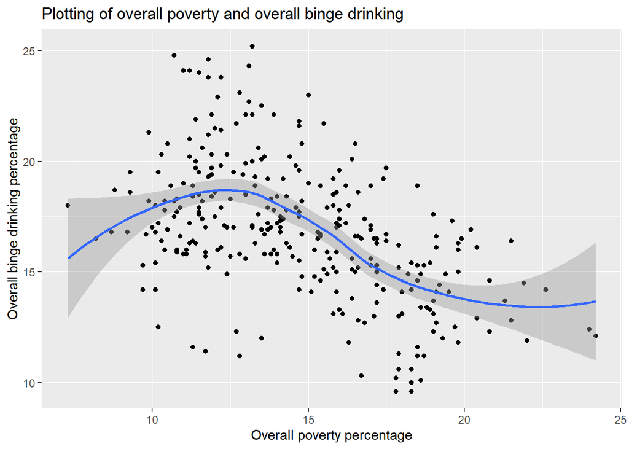

```r
# Change into proper structure
plot_data$poverty <- as.numeric(levels(plot_data$poverty)[plot_data$poverty])
plot_data$binge_all <- as.numeric(levels(plot_data$binge_all)[plot_data$binge_all])


# Create a ggplot
ggplot(data = plot_data, aes(x = poverty, y = binge_all)) +
  geom_point() +
  geom_smooth() +
  labs(title = "Plotting of overall poverty and overall binge drinking", x = "Overall poverty percentage", y = "Overall binge drinking percentage")
```

- Comment
  - The scatter plot shows that overall poverty and overall binge drinking have roughly negative correlation.
  - Smooth line shows that standard errors are greater in the lowest and higest overall poverty percentages.
  - Smooth line shows that correlation between overall poverty percentage and overall binge drinking percentage changes; correlation starts positive, takes a turn and changes to negative, then flattens as overall poverty percentage increases.

### **6. Calculate the average annual growth rates (in percent) of overall binge drinking across states for the years the data is available. One way to get these growth rates, is to group the data by state (dplyr::group_by) and use the first() and last() commands in the summarize command followed by dividing the calculated percentage increase by the number of years. Provide a table of the 5 states with the largest increases and the 5 states with the largest decreases in binge drinking prevalence over the time period.**

- Because United States, Puetro Rico, District of Columbia, Virgin Islands and Guam are not states, they will be removed. Also, growth rate cannot be calucated with blank data, so they will also be removed.

```r
# Create a new dataset for anlaysis, remove unncessary data
growth_data <- binge_clean %>%
  filter(stateabb != "US" & stateabb != "PR" & stateabb != "DC" & stateabb != "VI" & stateabb != "GU") %>%
  select(year, state, binge_all) %>%
  filter(!is.na(binge_all))

growth_data$binge_all <- as.numeric(levels(growth_data$binge_all)[growth_data$binge_all])

growth_data
```

| year | state | binge_all |
| --- | --- | --- |
| 2011 | Alaska | 20.8 |
| 2011 | Alabama | 13.7 |
| 2011 | Arkansas | 14.1 |
| 2011 | Arizona | 17.6 |
| 2011 | California | 18.6 |
| 2011 | Colorado | 20.1 |
| 2011 | Connecticut | 17.9 |
| 2011 | Delaware | 20.3 |
| 2011 | Florida | 17.1 |
| 2011 | Georgia | 16.6 |

[output cut: 290 more lines]

```r
# Calculate average growth rate
growth_data_1 <- growth_data %>%
  group_by(state) %>%
  summarise(base_yr = first(binge_all), last_yr = last(binge_all)) %>%
  mutate(avg_growth_rate = ((last_yr - base_yr)/base_yr)/5 * 100) %>%
  mutate(avg_growth_rate = round(avg_growth_rate, digits = 2)) %>%
  arrange(avg_growth_rate)

growth_data_1
```

| state | base_yr | last_yr | avg_growth_rate |
| --- | --- | --- | --- |
| Oklahoma | 16.5 | 11.8 | -5.70 |
| Georgia | 16.6 | 13.3 | -3.98 |
| Rhode Island | 19.6 | 15.8 | -3.88 |
| Delaware | 20.3 | 17.0 | -3.25 |
| Nevada | 18.6 | 15.8 | -3.01 |
| Maryland | 18.0 | 15.3 | -3.00 |
| Massachusetts | 20.6 | 17.8 | -2.72 |
| Hawaii | 21.5 | 18.6 | -2.70 |
| Illinois | 23.0 | 19.9 | -2.70 |
| Mississippi | 14.2 | 12.3 | -2.68 |

[output cut: 40 more lines]

```r
# Select top 5 and bottom 5 states, make it into a dataset
top_5 <- growth_data_1 %>%
  select(state, avg_growth_rate) %>%
  arrange(desc(avg_growth_rate)) %>%
  slice(1:5)

bottom_5 <- growth_data_1 %>%
  select(state, avg_growth_rate) %>%
  arrange(avg_growth_rate) %>%
  slice(1:5)


top_5_bottom_5 <- rbind(top_5, bottom_5)
```

- Below is a table of 10 states that had the highest average growth rate and lowest average growth rate for overall binge drinking percentage. Numbers are expressed in percentages.

```r
# Final dataset
knitr::kable(top_5_bottom_5, align = 'c', col.names =  c("State", "Avevrage Growth Rate in %"))
```

| State | Avevrage Growth Rate in % |
| --- | --- |
| Tennessee | 6.20 |
| West Virginia | 2.38 |
| South Carolina | 1.82 |
| Arkansas | 1.28 |
| Pennsylvania | 1.20 |
| Oklahoma | -5.70 |
| Georgia | -3.98 |
| Rhode Island | -3.88 |
| Delaware | -3.25 |
| Nevada | -3.01 |